# Applied Machine Learning in R

Modeling Wine Preferences by Data Mining and Physicochemical Properties

Jad Istanbelly

# Description

The data sets used in this project comprise of wine quality and their characteristics. There are two data sets:

1. Red wine and its physicochemical properties
2. White wine and its physicochemical properties

Let us take a look at them below

```r
# Clear Global Environment

remove(list = ls())

# Load Data and show in table

library(readr)
library(DT)
wine_red <- read.csv("C:/Users/jadel/OneDrive - Saint Marys University/Intro to Machine Learning/Data Sets/winequality-red.csv", sep = ";" )
wine_white <- read.csv("C:/Users/jadel/OneDrive - Saint Marys University/Intro to Machine Learning/Data Sets/winequality-white.csv", sep = ";")

datatable(wine_red, caption = "Red Wine")
```

|  | fixed.acidity | volatile.acidity | citric.acid | residual.sugar | chlorides | free.sulfur.dioxide | total.sulfur.dioxide | density | pH | sulphates | alcohol | quality |
| --- | --- | --- | --- | --- | --- | --- | --- | --- | --- | --- | --- | --- |
| 1 | 7.4 | 0.7 | 0 | 1.9 | 0.076 | 11 | 34 | 0.9978 | 3.51 | 0.56 | 9.4 | 5 |
| 2 | 7.8 | 0.88 | 0 | 2.6 | 0.098 | 25 | 67 | 0.9968 | 3.2 | 0.68 | 9.8 | 5 |
| 3 | 7.8 | 0.76 | 0.04 | 2.3 | 0.092 | 15 | 54 | 0.997 | 3.26 | 0.65 | 9.8 | 5 |
| 4 | 11.2 | 0.28 | 0.56 | 1.9 | 0.075 | 17 | 60 | 0.998 | 3.16 | 0.58 | 9.8 | 6 |
| 5 | 7.4 | 0.7 | 0 | 1.9 | 0.076 | 11 | 34 | 0.9978 | 3.51 | 0.56 | 9.4 | 5 |
| 6 | 7.4 | 0.66 | 0 | 1.8 | 0.075 | 13 | 40 | 0.9978 | 3.51 | 0.56 | 9.4 | 5 |
| 7 | 7.9 | 0.6 | 0.06 | 1.6 | 0.069 | 15 | 59 | 0.9964 | 3.3 | 0.46 | 9.4 | 5 |
| 8 | 7.3 | 0.65 | 0 | 1.2 | 0.065 | 15 | 21 | 0.9946 | 3.39 | 0.47 | 10 | 7 |
| 9 | 7.8 | 0.58 | 0.02 | 2 | 0.073 | 9 | 18 | 0.9968 | 3.36 | 0.57 | 9.5 | 7 |
| 10 | 7.5 | 0.5 | 0.36 | 6.1 | 0.071 | 17 | 102 | 0.9978 | 3.35 | 0.8 | 10.5 | 5 |

[output cut: 1589 more lines]

```r
datatable(wine_white, caption = "White Wine")
```

|  | fixed.acidity | volatile.acidity | citric.acid | residual.sugar | chlorides | free.sulfur.dioxide | total.sulfur.dioxide | density | pH | sulphates | alcohol | quality |
| --- | --- | --- | --- | --- | --- | --- | --- | --- | --- | --- | --- | --- |
| 1 | 7 | 0.27 | 0.36 | 20.7 | 0.045 | 45 | 170 | 1.001 | 3 | 0.45 | 8.8 | 6 |
| 2 | 6.3 | 0.3 | 0.34 | 1.6 | 0.049 | 14 | 132 | 0.994 | 3.3 | 0.49 | 9.5 | 6 |
| 3 | 8.1 | 0.28 | 0.4 | 6.9 | 0.05 | 30 | 97 | 0.9951 | 3.26 | 0.44 | 10.1 | 6 |
| 4 | 7.2 | 0.23 | 0.32 | 8.5 | 0.058 | 47 | 186 | 0.9956 | 3.19 | 0.4 | 9.9 | 6 |
| 5 | 7.2 | 0.23 | 0.32 | 8.5 | 0.058 | 47 | 186 | 0.9956 | 3.19 | 0.4 | 9.9 | 6 |
| 6 | 8.1 | 0.28 | 0.4 | 6.9 | 0.05 | 30 | 97 | 0.9951 | 3.26 | 0.44 | 10.1 | 6 |
| 7 | 6.2 | 0.32 | 0.16 | 7 | 0.045 | 30 | 136 | 0.9949 | 3.18 | 0.47 | 9.6 | 6 |
| 8 | 7 | 0.27 | 0.36 | 20.7 | 0.045 | 45 | 170 | 1.001 | 3 | 0.45 | 8.8 | 6 |
| 9 | 6.3 | 0.3 | 0.34 | 1.6 | 0.049 | 14 | 132 | 0.994 | 3.3 | 0.49 | 9.5 | 6 |
| 10 | 8.1 | 0.22 | 0.43 | 1.5 | 0.044 | 28 | 129 | 0.9938 | 3.22 | 0.45 | 11 | 6 |

[output cut: 4888 more lines]

There are two questions we will attempt to answer using these data sets:

1. Can we build a model that can predict white wine quality?
   - Using parametric and non-parametric methods
2. Can we build a model that can predict the wine type between red and white?
   - Using parametric and non-parametric methods

# Downloading and Preparing Data

This data is publicly available at [UCI](https://archive.ics.uci.edu/ml/datasets/Wine+Quality).

The first step that we need to do is to load our data into R and prepare/clean it before manipulating anything. Data cleaning is a very important step to ensure the quality of your data and to avoid any mistakes caused by unorganized or messy information.

## Cleaning

### Check Variable Classes

First step in cleaning is to take a look at the structure of each data frame and determine if all variables are in the correct class

```r
str(wine_red)
```

```
## 'data.frame':    1599 obs. of  12 variables:
##  $ fixed.acidity       : num  7.4 7.8 7.8 11.2 7.4 7.4 7.9 7.3 7.8 7.5 ...
##  $ volatile.acidity    : num  0.7 0.88 0.76 0.28 0.7 0.66 0.6 0.65 0.58 0.5 ...
##  $ citric.acid         : num  0 0 0.04 0.56 0 0 0.06 0 0.02 0.36 ...
##  $ residual.sugar      : num  1.9 2.6 2.3 1.9 1.9 1.8 1.6 1.2 2 6.1 ...
##  $ chlorides           : num  0.076 0.098 0.092 0.075 0.076 0.075 0.069 0.065 0.073 0.071 ...
##  $ free.sulfur.dioxide : num  11 25 15 17 11 13 15 15 9 17 ...
##  $ total.sulfur.dioxide: num  34 67 54 60 34 40 59 21 18 102 ...
##  $ density             : num  0.998 0.997 0.997 0.998 0.998 ...
##  $ pH                  : num  3.51 3.2 3.26 3.16 3.51 3.51 3.3 3.39 3.36 3.35 ...
##  $ sulphates           : num  0.56 0.68 0.65 0.58 0.56 0.56 0.46 0.47 0.57 0.8 ...
##  $ alcohol             : num  9.4 9.8 9.8 9.8 9.4 9.4 9.4 10 9.5 10.5 ...
##  $ quality             : int  5 5 5 6 5 5 5 7 7 5 ...
```

```r
str(wine_white)
```

```
## 'data.frame':    4898 obs. of  12 variables:
##  $ fixed.acidity       : num  7 6.3 8.1 7.2 7.2 8.1 6.2 7 6.3 8.1 ...
##  $ volatile.acidity    : num  0.27 0.3 0.28 0.23 0.23 0.28 0.32 0.27 0.3 0.22 ...
##  $ citric.acid         : num  0.36 0.34 0.4 0.32 0.32 0.4 0.16 0.36 0.34 0.43 ...
##  $ residual.sugar      : num  20.7 1.6 6.9 8.5 8.5 6.9 7 20.7 1.6 1.5 ...
##  $ chlorides           : num  0.045 0.049 0.05 0.058 0.058 0.05 0.045 0.045 0.049 0.044 ...
##  $ free.sulfur.dioxide : num  45 14 30 47 47 30 30 45 14 28 ...
##  $ total.sulfur.dioxide: num  170 132 97 186 186 97 136 170 132 129 ...
##  $ density             : num  1.001 0.994 0.995 0.996 0.996 ...
##  $ pH                  : num  3 3.3 3.26 3.19 3.19 3.26 3.18 3 3.3 3.22 ...
##  $ sulphates           : num  0.45 0.49 0.44 0.4 0.4 0.44 0.47 0.45 0.49 0.45 ...
##  $ alcohol             : num  8.8 9.5 10.1 9.9 9.9 10.1 9.6 8.8 9.5 11 ...
##  $ quality             : int  6 6 6 6 6 6 6 6 6 6 ...
```

The class of each variable looks ok. We can change “Quality” from an integer to numeric later on if needed. However, R defines Integer as a subset of Numeric and in most cases is treated the same.

### Check for Missing Values

Now we must check for any empty data points, NA’s, and incomplete rows and columns.

I have created a simple If/Else commands that checks for these and reports back with an appropriate statement.

```r
# Check for total NA's in DF

if (sum(is.na(wine_red)) == 0){
print("NA's do not exist in Red Wine")
} else { print("NA's exist in Red Wine")}
```

```
## [1] "NA's do not exist in Red Wine"
```

```r
if (sum(is.na(wine_white)) == 0){
print("NA's do not exist in White Wine")
} else { print("NA's exist in White Wine")}
```

```
## [1] "NA's do not exist in White Wine"
```

```r
# Check for total complete cases in DF

if (sum(complete.cases(wine_red)) == nrow(wine_red)){
print("Red Wine has no missing data points")
} else { print("Red Wine is missing data points")}
```

```
## [1] "Red Wine has no missing data points"
```

```r
if (sum(complete.cases(wine_white)) == nrow(wine_white)){
print("White Wine has no missing data points")
} else { print("White Wine is missing data points")}
```

```
## [1] "White Wine has no missing data points"
```

### Copy of Data-set

The final step is to create a copy of our data-sets.

As a general rule; it is better to edit, manipulate, and overwrite a copy of the data-sets rather than changing the original just so that you have something to revert back to if needed.

```r
dfr <- as.data.frame(wine_red)

dfw <- as.data.frame(wine_white)
```

# Important Notes before Analysis

1. All the models used in this document will be Bagged, run under loops for hundreds or thousands of times. This is done to maintain consistency/minimize over-fitting and to lower variance caused by randomly splitting data in train and test sets.
2. I will be tuning Hyper-parameters for each model if possible using a grid of parameter values. This is not a necessary step as it takes more computing power and time depending on specifications of your machine. However, it can increase accuracy so even a small to moderate sized grid search may help.
3. Our procedure for analysis will follow these steps:
   - Estimate Models and pick the top model by using AUC or RMSPE
   - Identify most important predictors in the top model
   - Report final decision by testing the top model with the test set
4. There are a lot of sections that contain a description earlier on in the document but not found in the later sections. This is simply to limit repetitive writing as most steps or code are very similar. If I have missed something that you would like clarification on please let me know!

# Predicting White Wine Quality

We can tackle this question differently depending on how we want to identify the problem. For instance:

1. Regression models will consider our dependent variable “Quality” as a continuous numeric variable and we will use Root Mean Square Percentage Error (RMSPE) and its uncertainty (SD) as metrics to make a final decision.
2. Classification models will split “Quality” into categories of “less than average” and “better than average”. We will use Area Under Curve (AUC) and its uncertainty (SD) as metrics to make a decision.

## Regression Problem

When working with a regression problem, we will be attempting to predict actual values of Quality.

For example; a white wine with, alcohol of 8, density of 1, pH of 3.5, etc. is predicted to be a quality of 7. This would also be known as Y and Y-hat or Actual and Predicted values.

### Splitting Data

Before we can estimate models we have to split our data into test and train subsets. The idea is to keep the test subset aside for our top model and so we will be further splitting our initial train set once more to assist us with validating and comparing our models first.

```r
# First Train and Test Split

ind <- sample(nrow(dfw), nrow(dfw)*0.90, replace = FALSE)
train <- dfw[ind, ]

# Save for later

test <- dfw[-ind, ]
```

### Estimating Models

Now we can run create and test various parametric and non-parametric models to determine which best suits our question.

#### Ordinary Least Squares (OLS)

OLS is used as a benchmark in comparison to other models in this document therefore, a linear multivariate regression is run to start our testing.

$$y = \beta_0 + \beta_1 x_1 + \beta_2 x_2 + \beta_3 x_3 ... \beta_n x_n$$

```r
library(doParallel)
library(scales)

# Detect and Store all but one core

ncores <- makeCluster(detectCores() - 1)

# Register # of cores

registerDoParallel(ncores)

# Set n for number of bags

n <- 500

# Empty containers are needed before loop starts

RMSPE0 <- c()

# Create Loop

rmspe_ols <-
  foreach(i = 1:n, .combine = c, .packages = "doParallel") %dopar% {

    # Second CV and Split

    ind1 <- sample(nrow(train), nrow(train), replace = TRUE)
    train1 <- train[ind1, ]
    test1 <- train[-ind1, ]

    # Create Model for each loop

    model0 <- lm(quality~., data = train1)

    # Predict Model for each loop

    yhat0 <- predict(model0, test1)

    # Calculate RMSPE for each loop

    RMSPE0[i] <- sqrt(mean((test1$quality - yhat0)^2))
}


# Unregister # of cores

stopCluster(ncores)

# Mean of RMSPE

MRMSPE0 <- percent(mean(rmspe_ols), accuracy = 0.01)

# Standard Deviation of RMSPE

uncer0 <- percent(sd(rmspe_ols), accuracy = 0.01)

# Create Results to compare the end of testing

results <- rbind(c("MRMSPE" = MRMSPE0, "SD" = uncer0))

# Create row name vector for results DF

rnames <- "OLS"

results
```

```
##      MRMSPE   SD
## [1,] "75.56%" "1.33%"
```

#### Classification and Regression Tree (CART)

##### Tuning Hyper-parameters

There are several Hyper-parameters using single decision trees, I have listed the ones I tuned below:

1. Complexity Parameter (CP) = The value that each split must increase the overall $R^2$ of the model by or else will be pruned.
2. Min split (MS) = The minimum amount of observations allowed per node before attempting to split
3. Max Depth (MD) = The maximum length taken from the root node to a leaf node, the tree will stop growing if MD is met.

```r
# Detect and Store all but one core

ncores <- makeCluster(detectCores() - 1)

# Register cores

registerDoParallel(ncores)

# Number of loops per grid combination

n <- 10

# Create Hyper-parameters

CP <- seq(0.01, 0.3, 0.01)
MS <- c(100, 300, 500, 750, 900)
MD <- 1:30

# Input Hyper-parameters into matrix and form a grid

grid <- as.matrix(expand.grid(MD, MS, CP))

# Empty Containers for loops to run

mse <-c()
sdmse <-c()
tuneresults <- c()

# Function to combine results of foreach loops in a master list
# This separates our two outputs into its correct list in our master list

comb <- function(x, ...) {
  lapply(seq_along(x),
    function(i) c(x[[i]], lapply(list(...), function(y) y[[i]])))
}

# Parallelized Loop

tuneresults <- foreach(i = 1:nrow(grid), .combine = comb,
                       .packages = c("rpart", "doParallel"), .multicombine = TRUE,
                       .init=list(list(), list())) %dopar% {

                         test_mse <- c()

                         for (j in 1:n) { # run grid selection this many times

                           # Second CV

                           ind1 <- sample(nrow(train), nrow(train), replace = TRUE)
                           train1 <- train[ind1, ]
                           test1 <- train[-ind1, ]

                           # Create model for each loop

                           cart <- rpart(quality~., minsplit = grid[i, 2],
                                         cp = grid[i, 3], maxdepth = grid[i, 1],
                                         data = train1, method = "anova")

                           # Predict Y-hats for each loop

                           cartpr <- predict(cart, test1)

                           # Calculate MSE for each loop

                            test_mse[j] <- mean((test1$quality - cartpr)^2)
                         }

                         # Find Mean and SD of all MSE's per grid selection

                         mse[i] <- mean(test_mse)
                         sdmse[i] <- sd(test_mse)

                         # Store Results in a list

                         list(mse[i], sdmse[[i]])
                       }

# Detach/Unregister cores

stopCluster(ncores)

# Extract MSE and Turn into vector

mse <- unlist(tuneresults[[1]])
sdmse <- unlist(tuneresults[[2]])

# Min MSE and Mean of SD

mmse <- min(mse)
msdmse <- mean(sdmse)

# Create table and showcase results
# Find the Hyper-parameters that give the lowest MSE

tunedcart <- rbind(c(grid[which.min(mse), ], mmse, msdmse))
colnames(tunedcart) <- c("MD", "MS", "CP","MMSE", "SD")

tunedcart
```

```
##      MD  MS   CP      MMSE        SD
## [1,] 15 100 0.01 0.5699897 0.0255427
```

##### Validating Model

Now we can use the best parameters as shown above from our grid to validate our model.

```r
# Detect and Store all but one core

ncores <- makeCluster(detectCores() - 1)

# Register cores

registerDoParallel(ncores)

# Set N for number of bags

n <- 500

# Empty containers are needed before loop starts

RMSPE1 <- c()

rmspe_cart <-
  foreach(i = 1:n, .combine = c, .packages = c("rpart","doParallel")) %dopar% {

    # Second CV and Split

    ind1 <- sample(nrow(train), nrow(train), replace = TRUE)
    train1 <- train[ind1, ]
    test1 <- train[-ind1, ]

    # Create Model for each loop

    model1 <- rpart(quality~.,
                  minsplit = tunedcart[2], cp = tunedcart[3], maxdepth = tunedcart[1],
                  data = train1, method = "anova")

    # Predict Model for each loop

    yhat1 <- predict(model1, test1)

    # Calculate RMSPE for each loop

    RMSPE1[i] <- sqrt(mean((test1$quality - yhat1)^2))
  }

# Unregister # of cores

stopCluster(ncores)

# Mean of RMSPE

MRMSPE1 <- percent(mean(rmspe_cart), accuracy = 0.01)

# Standard Deviation of RMSPE

uncer1 <- percent(sd(rmspe_cart), accuracy = 0.01)

# Combine new values into matrix

values1 <- cbind(MRMSPE1, uncer1)

# Match colnames to append new values into Results

names(values1) <- names(results)
results <- rbind(results, values1)

# Update Row Names

rnames <- append(rnames, "CART", length(rnames))

values1
```

```
##      MRMSPE1  uncer1
## [1,] "76.38%" "1.39%"
```

#### K-Nearest Neighbors

##### Tuning Hyper-parameters

There is a single hyper-parameter that has been tuned using KNN, this would be:

1. K = number of neighbors considered when evaluating the average value of a new data point

```r
# Detect and Store all but one core

ncores <- makeCluster(detectCores() - 1)

# Register cores

registerDoParallel(ncores)

# Number of loops per grid combination

n <- 10

# Create Hyper-parameter

k <- seq(from = 2, to = sqrt(nrow(train)), by = 1) # Number of neighbors considered

# Empty Containers for loops to run

mse <-c()
sdmse <-c()
tuneresults <- c()

# Parallelized Loop

tuneresults <- foreach(i = 1:length(k), .combine = comb,
                       .packages = c("caret", "doParallel"), .multicombine = TRUE,
                       .init=list(list(), list())) %dopar% {

                         test_mse <- c()

                         for (j in 1:n) { # run grid selection this many times

                           # Second CV

                           ind1 <- sample(nrow(train), nrow(train), replace = TRUE)
                           train1 <- train[ind1, ]
                           test1 <- train[-ind1, ]

                           # Create model for each loop

                           knnt <- knnreg(quality~., data = train1, k = k[i])

                           # Predict Y-hats for each loop

                           knnpr <- predict(knnt, test1, method = "knn")

                           # Calculate MSE for each loop

                           test_mse[j] <- mean((test1$quality - knnpr)^2)
                         }

                         # Find Mean and SD of all MSE's per grid selection

                         mse[i] <- mean(test_mse)
                         sdmse[i] <- sd(test_mse)

                         # Store Results in a list

                         list(mse[i], sdmse[[i]])
                       }

# Detach/Unregister cores

stopCluster(ncores)

# Extract MSE and Turn into vector

mse <- unlist(tuneresults[[1]])
sdmse <- unlist(tuneresults[[2]])

# Min MSE and Mean of SD

mmse <- min(mse)
msdmse <- mean(sdmse)

# Create table and showcase results
# Find the Hyper-parameters that give the lowest MSE

tunedknn <- rbind(c(k[which.min(mse)], mmse, msdmse))
colnames(tunedknn) <- c("K","MMSE", "SD")

tunedknn
```

```
##       K      MMSE         SD
## [1,] 48 0.6650682 0.02132373
```

##### Validating Model

```r
# Detect and Store all but one core

ncores <- makeCluster(detectCores() - 1)

# Register cores

registerDoParallel(ncores)

# Set N for number of bags

n <- 500

# Empty containers are needed before loop starts

RMSPE2 <- c()

rmspe_k <-
  foreach(i = 1:n, .combine = c, .packages = c("caret","doParallel")) %dopar% {

    # Second CV and Split

    ind1 <- sample(nrow(train), nrow(train), replace = TRUE)
    train1 <- train[ind1, ]
    test1 <- train[-ind1, ]

    # Create Model for each loop

    model2 <- knnreg(quality~., data = train1, k = tunedknn[1])

    # Predict Model for each loop

    yhat2 <- predict(model2, test1)

    # Calculate RMSPE for each loop

    RMSPE2[i] <- sqrt(mean((test1$quality - yhat2)^2))
  }

# Unregister # of cores

stopCluster(ncores)

# Mean of RMSPE

MRMSPE2 <- percent(mean(rmspe_k), accuracy = 0.01)

# Standard Deviation of RMSPE

uncer2 <- percent(sd(rmspe_k), accuracy = 0.01)

# Combine new values into matrix

values2 <- cbind(MRMSPE2, uncer2)

# Match colnames to append new values into Results

names(values2) <- names(results)
results <- rbind(results, values2)

# Update Row Names

rnames <- append(rnames, "KNN", length(rnames))

values2
```

```
##      MRMSPE2  uncer2
## [1,] "82.37%" "1.25%"
```

#### Random Forest (RF)

##### Tuning Hyper-parameters

There are several possible parameters to tune, these are the ones that I have experimented with:

1. Number of Trees (NT) = Number of trees to grow in a forest
2. Number of Variables (MT) = Amount of variables that are randomly selected at each split

```r
# Detect and Store all but one core

ncores <- makeCluster(detectCores() - 1)

# Register cores

registerDoParallel(ncores)

# Number of loops per grid combination

n <- 10

# Create Hyper-parameters

NT <- seq(1000, 2000, 200) # Number of Trees
p <- ncol(train)-1 # Amount of x-variables
MT <- p/3:p # p/3 is default for regression

# Input Hyper-parameters into matrix and form a grid

grid <- as.matrix(expand.grid(NT, MT))

# Empty Containers for loops to run

mse <-c()
sdmse <-c()
tuneresults <- c()

# Parallelized Loop

tuneresults <- foreach(i = 1:nrow(grid), .combine = comb,
                       .packages = c("ranger", "doParallel"), .multicombine = TRUE,
                       .init=list(list(), list())) %dopar% {

                         test_mse <- c()

                         for (j in 1:n) { # run grid selection this many times

                           # Second CV

                           ind1 <- sample(nrow(train), nrow(train), replace = TRUE)
                           train1 <- train[ind1, ]
                           test1 <- train[-ind1, ]

                           # Create model for each loop

                           rft <- ranger(y = train1[, 12], x = train1[, 1:11],
                                         num.trees = grid[i, 1], mtry = grid[i, 2])

                           # Predict Y-hats for each loop

                           rfpr <- predict(rft, test1)

                           # Calculate MSE for each loop

                           test_mse[j] <- mean((test1$quality - rfpr$predictions)^2)
                         }

                         # Find Mean and SD of all MSE's per grid selection

                         mse[i] <- mean(test_mse)
                         sdmse[i] <- sd(test_mse)

                         # Store Results in a list

                         list(mse[i], sdmse[[i]])
                       }

# Detach/Unregister cores

stopCluster(ncores)

# Extract MSE and Turn into vector

mse <- unlist(tuneresults[[1]])
sdmse <- unlist(tuneresults[[2]])

# Min MSE and Mean of SD

mmse <- min(mse)
msdmse <- mean(sdmse)

# Create table and showcase results
# Find the Hyper-parameters that give the lowest MSE

tunedrf <- rbind(c(grid[which.min(mse), ], mmse, msdmse))
colnames(tunedrf) <- c("NT","MT", "MMSE", "SD")

tunedrf
```

```
##        NT       MT      MMSE         SD
## [1,] 1800 3.666667 0.3858319 0.01609822
```

##### Validating Model

```r
# Detect and Store all but one core

ncores <- makeCluster(detectCores() - 1)

# Register cores

registerDoParallel(ncores)

# Set N for number of bags

n <- 500

# Empty containers are needed before loop starts

RMSPE3 <- c()

rmspe_rf <-
  foreach(i = 1:n, .combine = c, .packages = c("ranger","doParallel")) %dopar% {

    # Second CV and Split

    ind1 <- sample(nrow(train), nrow(train), replace = TRUE)
    train1 <- train[ind1, ]
    test1 <- train[-ind1, ]

    # Create Model for each loop

    model3 <- ranger(y = train1[, 12], x = train1[, 1:11],num.trees = tunedrf[1],
                     mtry = tunedrf[2])

    # Predict Model for each loop

    yhat3 <- predict(model3, test1)

    # Calculate RMSPE for each loop

    RMSPE3[i] <- sqrt(mean((test1$quality - yhat3$predictions)^2))
  }

# Unregister # of cores

stopCluster(ncores)

# Mean of RMSPE

MRMSPE3 <- percent(mean(rmspe_rf), accuracy = 0.01)

# Standard Deviation of RMSPE

uncer3 <- percent(sd(rmspe_rf), accuracy = 0.01)

# Combine new values into matrix

values3 <- cbind(MRMSPE3, uncer3)

# Match colnames to append new values into Results

names(values3) <- names(results)
results <- rbind(results, values3)

# Update Row Names

rnames <- append(rnames, "RF", length(rnames))

values3
```

```
##      MRMSPE3  uncer3
## [1,] "63.00%" "1.40%"
```

#### Gradient Boosting Machines (GBM)

##### Tuning Hyper-parameters

The hyper-parameters tuned are:

1. Shrinkage (SH) = The rate at which each expansion step is reduced by, this is also known as the learning rate
2. N.Trees (NT) = Total number of trees to fit
3. Interaction Depth (ID) = Number of splits in each tree

```r
# Detect and Store all but one core

ncores <- makeCluster(detectCores() - 1)

# Register cores

registerDoParallel(ncores)

# Number of loops per grid combination

n <- 10

# Create Hyper-parameters

SH <- seq(0.01, 0.3, 0.01) # Shrinkage default = 0.1
NT <- c(100, 300, 500, 750, 900) # Number of predicted trees default = 100
ID <- 1:sqrt(ncol(train)) # Interaction Depth default = 1

# Input Hyper-parameters into matrix and form a grid

grid <- as.matrix(expand.grid(ID, NT, SH))

# Empty Containers for loops to run

mse <-c()
sdmse <-c()
tuneresults <- c()

# Parallelized Loop

tuneresults <- foreach(i = 1:nrow(grid), .combine = comb,
                       .packages = c("gbm", "doParallel"), .multicombine = TRUE,
                       .init=list(list(), list())) %dopar% {

                         test_mse <- c()

                         for (j in 1:n) { # run grid selection this many times

                           # Second CV

                           ind1 <- sample(nrow(train), nrow(train), replace = TRUE)
                           train1 <- train[ind1, ]
                           test1 <- train[-ind1, ]

                           # Create model for each loop

                           boos <- gbm(quality~., distribution ="gaussian",
                                       n.trees=1000,interaction.depth = grid[i,1],
                                       shrinkage = grid[i,3], data = train1)

                           # Predict Y-hats for each loop

                           prboos <- predict(boos, test1, n.trees = grid[i,2])

                           # Calculate MSE for each loop

                           test_mse[j] <- mean((test1$quality - prboos)^2)
                         }

                         # Find Mean and SD of all MSE's per grid selection

                         mse[i] <- mean(test_mse)
                         sdmse[i] <- sd(test_mse)

                         # Store Results in a list

                         list(mse[i], sdmse[[i]])
                       }

# Detach/Unregister cores

stopCluster(ncores)

# Extract MSE and Turn into vector

mse <- unlist(tuneresults[[1]])
sdmse <- unlist(tuneresults[[2]])

# Min MSE and Mean of SD

mmse <- min(mse)
msdmse <- mean(sdmse)

# Create table and showcase results
# Find the Hyper-parameters that give the lowest MSE

tunedboost <- rbind(c(grid[which.min(mse), ], mmse, msdmse))
colnames(tunedboost) <- c("ID", "NT", "SH", "MMSE", "SD")

tunedboost
```

```
##      ID  NT   SH      MMSE         SD
## [1,]  2 900 0.06 0.4685274 0.01702344
```

##### Validating Model

```r
# Detect and Store all but one core

ncores <- makeCluster(detectCores() - 1)

# Register cores

registerDoParallel(ncores)

# Set N for number of bags

n <- 500

# Empty containers are needed before loop starts

RMSPE4 <- c()

rmspe_gbm <-
  foreach(i = 1:n, .combine = c, .packages = c("gbm","doParallel")) %dopar% {

    # Second CV and Split

    ind1 <- sample(nrow(train), nrow(train), replace = TRUE)
    train1 <- train[ind1, ]
    test1 <- train[-ind1, ]

    # Create Model for each loop

    model4 <- gbm(quality~., distribution ="gaussian", n.trees=1000,
                  interaction.depth = tunedboost[1], shrinkage = tunedboost[3],
                  data = train1)

    # Predict Model for each loop

    yhat4 <- predict(model4, test1, n.trees = tunedboost[2])

    # Calculate RMSPE for each loop

    RMSPE4[i] <- sqrt(mean((test1$quality - yhat4)^2))
  }

# Unregister # of cores

stopCluster(ncores)

# Mean of RMSPE

MRMSPE4 <- percent(mean(rmspe_gbm), accuracy = 0.01)

# Standard Deviation of RMSPE

uncer4 <- percent(sd(rmspe_gbm), accuracy = 0.01)

# Combine new values into matrix

values4 <- cbind(MRMSPE4, uncer4)

# Match colnames to append new values into Results

names(values4) <- names(results)
results <- rbind(results, values4)

# Update Row Names

rnames <- append(rnames, "GBM", length(rnames))

values4
```

```
##      MRMSPE4  uncer4
## [1,] "69.69%" "1.17%"
```

### Compare Results and Pick a Winner

We can either use a table like this and manually filter and decide which model yields the lowest Minimum Root Mean Square Prediction Error

```r
# Combine all results with its corresponding model

rownames(results) <- rnames

datatable(results, colnames = c("Model" = 1))
```

| Model | MRMSPE | SD |
| --- | --- | --- |
| OLS | 75.56% | 1.33% |
| CART | 76.38% | 1.39% |
| KNN | 82.37% | 1.25% |
| RF | 63.00% | 1.40% |
| GBM | 69.69% | 1.17% |

Or we can just ask R to look for the minimum RMSPE from all models:

```r
# Remove % sign to refrain from NA

results_RMSPE <- as.numeric(sub("%", "", results[, 1]))

# Find min RMSPE from all models

results[which.min(results_RMSPE), ]
```

```
##   MRMSPE       SD
## "63.00%"  "1.40%"
```

Looks like Random Forest is the model with the lowest RMSPE

### Most Important Predictors

Below is a chart of our variables ranked based on their increase in MSE this is done by permuting a X variable thus randomizing its values then making note of the change in MSE. This process is done to every X variable then the variables with the highest change in MSE is deemed important as it would hurt the model to not include them. In other words, the top predictors better explain “quality of White wine” and should not be omitted from our analysis

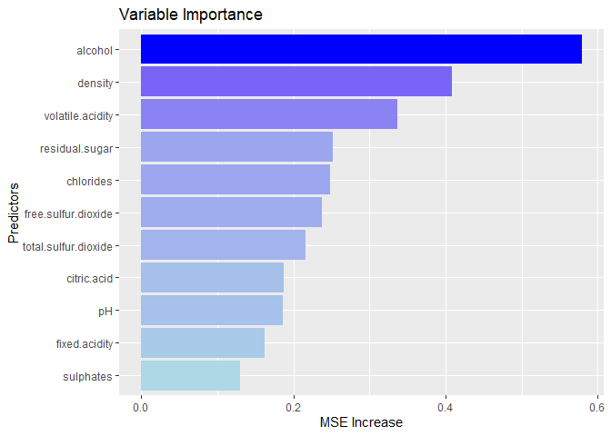

```r
# doParallel does not store the models we have run so recreate the winner model below

library(ranger)

ind1 <- sample(nrow(train), nrow(train), replace = TRUE)
train1 <- train[ind1, ]

model3 <- ranger(y = train1[, 12], x = train1[, 1:11],num.trees = tunedrf[1],
                     mtry = tunedrf[2], importance = "permutation")

# Create DF of Variable Importance

imppred <- as.data.frame(model3$variable.importance)
colnames(imppred) <- "importance"

# Plot values on Bar graph

library(ggplot2)
ggplot(imppred, aes(x=reorder(row.names(imppred),importance),
                    y=importance,fill=importance))+
  geom_bar(stat="identity", position="dodge")+ coord_flip()+
  ylab("MSE Increase")+
  xlab("Predictors")+
  ggtitle("Variable Importance")+
  guides(fill=F)+
  scale_fill_gradient(low="light blue", high="blue")
```

### Running Test on Winner

Since we only have 10% of the data to use to test our top model, we can cross-validate and shuffle the original split to retrieve new 10% sets of data to run on. Essentially, we are bagging the top model once more using the full set of data rather than the smaller portion used for validating.

```r
# Detect and Store all but one core

ncores <- makeCluster(detectCores() - 1)

# Register cores

registerDoParallel(ncores)

# Set N for number of bags

n <- 500

# Empty containers are needed before loop starts

RMSPEW <- c()

rmspe_w <-
  foreach(i = 1:n, .combine = c, .packages = c("ranger","doParallel")) %dopar% {

    # Initial CV and Split

    ind <- sample(nrow(dfw), nrow(dfw)*0.90, replace = FALSE)
    train <- dfw[ind, ]
    test <- dfw[-ind1, ]

    # Create Model for each loop

    modelw <- ranger(y = train[, 12], x = train[, 1:11],
                         num.trees = tunedrf[1], mtry = tunedrf[2])

    # Predict Model for each loop

    yhatw <- predict(modelw, test)

    # Calculate RMSPE for each loop

    RMSPEW[i] <- sqrt(mean((test$quality - yhatw$predictions)^2))
  }

# Unregister # of cores

stopCluster(ncores)

# Mean of RMSPE

MRMSPEW <- percent(mean(rmspe_rf), accuracy = 0.01)

# Standard Deviation of RMSPE

uncerW <- percent(sd(rmspe_rf), accuracy = 0.01)

# Create matrix of Winner Root Mean Square Prediction Error

resultsw <- cbind("Model" = "Random Forest", "RMSPE" = MRMSPEW, "SD" = uncerW)

resultsw
```

```
##      Model           RMSPE    SD
## [1,] "Random Forest" "63.00%" "1.40%"
```

## Classification Problem

When working with a Classification problem, we will be attempting to predict classes/groups of Quality.

For example; a white wine with, alcohol of 8, density of 1, pH of 3.5, etc. is predicted to be above average in Quality.

### Pre-processing Steps

As mentioned previously, we will split “Quality” to a Binary variable with the following outcomes:

1. Below Average
2. Above Average

Then create our initial test and train split

```r
remove(list = ls())
library(readr)

# Load Data into R

winequality_white <- read.csv("C:/Users/jadel/OneDrive - Saint Marys University/Intro to Machine Learning/Data Sets/winequality-white.csv", sep = ";")

# Make a copy of Data

dfw <- winequality_white

# If Quality is above average then assign a 1 if not then assign a 0

dfw$quality <- ifelse(dfw$quality > mean(dfw$quality), 1 , 0)

# Initial Split

ind <- sample(nrow(dfw), nrow(dfw)*0.90, replace = FALSE)
train <- dfw[ind, ]
test <- dfw[-ind, ]
```

### Estimating Models

#### Linear Probability Model (LPM)

LPM is used as a benchmark in comparison to other Classification models in this document

```r
# Detect and Store all but one core

ncores <- makeCluster(detectCores() - 1)

# Register # of cores

registerDoParallel(ncores)

# Set n for number of bags

n <- 500

# Empty containers are needed before loop starts

AUC0 <- c()

# Create Loop

auc_ols <-
  foreach(i = 1:n, .combine = c, .packages = c("doParallel", "ROCR")) %dopar% {

    # Second CV and Split

    ind1 <- sample(nrow(train), nrow(train), replace = TRUE)
    train1 <- train[ind1, ]
    test1 <- train[-ind1, ]

    # Create Model for each loop

    model0 <- lm(quality~., data = train1)

    # Predict Model for each loop

    phat0 <- predict(model0, test1)


    # Predict and Calculate AUC for each loop

    pred_rocr0 <- prediction(phat0, test1$quality)
    auc_ROCR0 <- performance(pred_rocr0, measure = "auc")
    AUC0[i] <- auc_ROCR0@y.values[[1]]
}


# Unregister # of cores

stopCluster(ncores)

# Mean of AUC

MAUC0 <- percent(mean(auc_ols), accuracy = 0.01)

# Standard Deviation of AUC

uncer0 <- percent(sd(auc_ols), accuracy = 0.01)

# Create Results to compare the end of testing

results <- rbind(c("MAUC" = MAUC0, "SD" = uncer0))

# Create row name vector for results DF

rnames <- "LPM"

results
```

```
##      MAUC     SD
## [1,] "80.13%" "0.97%"
```

#### Classification and Regression Tree (CART)

##### Tuning Hyper-parameters

The same parameters are tuned here as with the regression example above except for a slight change in definition for CP:

- The Complexity Parameter is the minimum improvement needed at each node of the model or else it will be pruned.

```r
# Detect and Store all but one core

ncores <- makeCluster(detectCores() - 1)

# Register cores

registerDoParallel(ncores)

# Number of loops per grid combination

n <- 10

# Create Hyper-parameters

CP <- seq(0.01, 0.3, 0.01) # Complexity Parameter
MS <- c(100, 300, 500, 750, 900) # Min Split
MD <- 1:30 # Max Depth

# Input Hyper-parameters into matrix and form a grid

grid <- as.matrix(expand.grid(MD, MS, CP))

# Empty Containers for loops to run

mauc <- c()
sdauc <- c()
tuneresults <- c()

# Function to combine results of foreach loops in a master list
# This separates our two outputs into its correct list in our master list

comb <- function(x, ...) {
  lapply(seq_along(x),
    function(i) c(x[[i]], lapply(list(...), function(y) y[[i]])))
}

# Parallelized Loop

tuneresults <- foreach(i = 1:nrow(grid), .combine = comb,
                       .packages = c("rpart", "doParallel", "ROCR"),
                       .multicombine = TRUE,.init=list(list(), list())) %dopar% {

                         auc <- c() # Store calculated AUC from each loop

                         for (j in 1:n) { # run grid selection this many times

                           # Second CV

                           ind1 <- sample(nrow(train), nrow(train), replace = TRUE)
                           train1 <- train[ind1, ]
                           test1 <- train[-ind1, ]

                           # Create model for each loop

                          cart <- rpart(quality~., minsplit = grid[i, 2],
                                        cp = grid[i, 3], maxdepth = grid[i, 1],
                                        data = train1, method = "class")

                          # Predict P-hats for each loop

                          cartpr <- predict(cart, test1, type = "prob") [, 2]

                          # Predict and Calculate AUC for each loop

                          pred_rocr1 <- prediction(cartpr, test1$quality)
                          auc_ROCR1 <- performance(pred_rocr1, measure = "auc")
                          auc[j] <- auc_ROCR1@y.values[[1]]
                         }

                         # Find Mean and SD of all AUC's per grid selection

                          mauc[i] <- mean(auc)
                          sdauc[i] <- sd(auc)

                         # Store Results in a list

                         list(mauc[i], sdauc[[i]])
                       }

# Detach/Unregister cores

stopCluster(ncores)

# Extract AUC and Turn into vector

mauc <- unlist(tuneresults[[1]])
sdauc <- unlist(tuneresults[[2]])

# Max MAUC and Mean of SD

mmauc <- max(mauc)
msdauc <- mean(sdauc)

# Create table and showcase results
# Find the Hyper-parameters that give the Highest AUC

tunedcart <- rbind(c(grid[which.max(mauc), ], mmauc, msdauc))
colnames(tunedcart) <- c("MD", "MS", "CP","Max MAUC", "SD")

tunedcart
```

```
##      MD  MS   CP  Max MAUC         SD
## [1,] 22 100 0.01 0.7542423 0.01524507
```

##### Validating Model

```r
# Detect and Store all but one core

ncores <- makeCluster(detectCores() - 1)

# Register # of cores

registerDoParallel(ncores)

# Set n for number of bags

n <- 500

# Empty containers are needed before loop starts

AUC1 <- c()

# Create Loop

auc_cart <-
  foreach(i = 1:n, .combine = c,
          .packages = c("doParallel", "ROCR", "rpart")) %dopar% {

    # Second CV and Split

    ind1 <- sample(nrow(train), nrow(train), replace = TRUE)
    train1 <- train[ind1, ]
    test1 <- train[-ind1, ]

    # Create Model for each loop

    model1 <- rpart(quality~., minsplit = tunedcart[2], cp = tunedcart[3],
                    maxdepth = tunedcart[1], data = train1, method = "class")

    # Predict Model for each loop

    phat1 <- predict(model1, test1, type = "prob")[, 2]

  # Predict and Calculate AUC for each loop

    pred_rocr1 <- prediction(phat1, test1$quality)
    auc_ROCR1 <- performance(pred_rocr1, measure = "auc")
    AUC1[i] <- auc_ROCR1@y.values[[1]]
}


# Unregister # of cores

stopCluster(ncores)

# Mean of AUC

MAUC1 <- percent(mean(auc_cart), accuracy = 0.01)

# Standard Deviation of AUC

uncer1 <- percent(sd(auc_cart), accuracy = 0.01)

# Create Results to compare the end of testing

values1 <- rbind(c("MAUC" = MAUC1, "SD" = uncer1))

# Match colnames to append new values into Results

names(values1) <- names(results)
results <- rbind(results, values1)

# Update Row Names

rnames <- append(rnames, "CART", length(rnames))

values1
```

```
##      MAUC     SD
## [1,] "74.63%" "1.65%"
```

#### K-Nearest Neighbors

##### Tuning Hyper-parameters

The same parameters are tuned here as with the regression example above

```r
# Detect and Store all but one core

ncores <- makeCluster(detectCores() - 1)

# Register cores

registerDoParallel(ncores)

# Number of loops per grid combination

n <- 10

# Create Hyper-parameters

k <- seq(from = 2, to = sqrt(nrow(train)), by = 1) # Number of neighbors considered

# Empty Containers for loops to run

mauc <- c()
sdauc <- c()
tuneresults <- c()

# Parallelized Loop

tuneresults <- foreach(i = 1:length(k), .combine = comb,
                       .packages = c("caret", "doParallel", "ROCR"),
                       .multicombine = TRUE,.init=list(list(), list())) %dopar% {

                         auc <- c() # Store calculated AUC from each loop

                         for (j in 1:n) { # run grid selection this many times

                           # Second CV

                           ind1 <- sample(nrow(train), nrow(train), replace = TRUE)
                           train1 <- train[ind1, ]
                           test1 <- train[-ind1, ]

                           # Create model for each loop

                           knnt <- knn3(quality~., data = train1, k = k[i])

                           # Predict P-hats for each loop

                           knnpr <- predict(knnt, test1, method = "prob")[, 2]

                           # Predict and Calculate AUC for each loop

                           pred_rocr2 <- prediction(knnpr, test1$quality)
                           auc_ROCR2 <- performance(pred_rocr2, measure = "auc")
                           auc[j] <- auc_ROCR2@y.values[[1]]
                         }

                         # Find Mean and SD of all AUC's per grid selection

                          mauc[i] <- mean(auc)
                          sdauc[i] <- sd(auc)

                         # Store Results in a list

                         list(mauc[i], sdauc[[i]])
                       }

# Detach/Unregister cores

stopCluster(ncores)

# Extract AUC and Turn into vector

mauc <- unlist(tuneresults[[1]])
sdauc <- unlist(tuneresults[[2]])

# Max MAUC and Mean of SD

mmauc2 <- max(mauc)
msdauc2 <- mean(sdauc)

# Create table and showcase results
# Find the Hyper-parameters that give the Highest AUC

tunedknn <- rbind(c(k[which.max(mauc) ], mmauc2, msdauc2))
colnames(tunedknn) <- c("K", "Max MAUC", "SD")

tunedknn
```

```
##       K Max MAUC         SD
## [1,] 62 0.705923 0.01030712
```

##### Validating Model

```r
# Detect and Store all but one core

ncores <- makeCluster(detectCores() - 1)

# Register # of cores

registerDoParallel(ncores)

# Set n for number of bags

n <- 500

# Empty containers are needed before loop starts

AUC2 <- c()

# Create Loop

auc_k <-
  foreach(i = 1:n, .combine = c,
          .packages = c("doParallel", "ROCR", "caret")) %dopar% {

    # Second CV and Split

    ind1 <- sample(nrow(train), nrow(train), replace = TRUE)
    train1 <- train[ind1, ]
    test1 <- train[-ind1, ]

    # Create Model for each loop

    model2 <- knn3(quality~., data = train1, k = tunedknn[1])

    # Predict Model for each loop

    phat2 <- predict(model2, test1, type = "prob")[, 2]

    # Predict and Calculate AUC for each loop

    pred_rocr2 <- prediction(phat2, test1$quality)
    auc_ROCR2 <- performance(pred_rocr2, measure = "auc")
    AUC2[i] <- auc_ROCR2@y.values[[1]]
}


# Unregister # of cores

stopCluster(ncores)

# Mean of AUC

MAUC2 <- percent(mean(auc_k), accuracy = 0.01)

# Standard Deviation of AUC

uncer2 <- percent(sd(auc_k), accuracy = 0.01)

# Create Results to compare the end of testing

values2 <- rbind(c("MAUC" = MAUC2, "SD" = uncer2))

# Match colnames to append new values into Results

names(values2) <- names(results)
results <- rbind(results, values2)

# Update Row Names

rnames <- append(rnames, "KNN", length(rnames))

values2
```

```
##      MAUC     SD
## [1,] "69.79%" "1.05%"
```

#### Random Forest (RF)

##### Tuning Hyper-parameters

The same parameters are tuned here as with the regression example above

```r
# Detect and Store all but one core

ncores <- makeCluster(detectCores() - 1)

# Register cores

registerDoParallel(ncores)

# Number of loops per grid combination

n <- 10

# Create Hyper-parameters

NT <- seq(1000, 2000, 200) # Number of Trees
p <- ncol(train)-1 # Amount of x-variables
MT <- sqrt(p):p # Number of X-variables used sqrt(p) is default for Classification

# Input Hyper-parameters into matrix and form a grid

grid <- as.matrix(expand.grid(NT, MT))

# Empty Containers for loops to run

mauc <- c()
sdauc <- c()
tuneresults <- c()

# Parallelized Loop

tuneresults <- foreach(i = 1:nrow(grid), .combine = comb,
                       .packages = c("ranger", "doParallel", "ROCR"),
                       .multicombine = TRUE,.init=list(list(), list())) %dopar% {

                         auc <- c() # Store calculated AUC from each loop

                         for (j in 1:n) { # run grid selection this many times

                           # Second CV

                           ind1 <- sample(nrow(train), nrow(train), replace = TRUE)
                           train1 <- train[ind1, ]
                           test1 <- train[-ind1, ]

                           # Create model for each loop
                           rft <- ranger(y = train1[, 12], x = train1[, 1:11],
                                         num.trees = grid[i, 1], mtry = grid[i, 2],
                                         probability = TRUE)

                           # Predict P-hats for each loop
                           rfpr <- predict(rft, test1,
                                           type = "response")$predictions[, 2]

                           # Predict and Calculate AUC for each loop

                           pred_rocr3 <- prediction(rfpr, test1$quality)
                           auc_ROCR3 <- performance(pred_rocr3, measure = "auc")
                           auc[j] <- auc_ROCR3@y.values[[1]]
                         }

                         # Find Mean and SD of all AUC's per grid selection

                          mauc[i] <- mean(auc)
                          sdauc[i] <- sd(auc)

                         # Store Results in a list

                         list(mauc[i], sdauc[[i]])
                       }

# Detach/Unregister cores

stopCluster(ncores)

# Extract AUC and Turn into vector

mauc <- unlist(tuneresults[[1]])
sdauc <- unlist(tuneresults[[2]])

# Max MAUC and Mean of SD

mmauc3 <- max(mauc)
msdauc3 <- mean(sdauc)

# Create table and showcase results
# Find the Hyper-parameters that give the Highest AUC

tunedrf <- rbind(c(grid[which.max(mauc), ], mmauc3, msdauc3))
colnames(tunedrf) <- c("NT","MT", "Max MAUC", "SD")

tunedrf
```

```
##        NT       MT  Max MAUC        SD
## [1,] 1600 5.316625 0.6509216 0.3567449
```

##### Validating Model

```r
# Detect and Store all but one core

ncores <- makeCluster(detectCores() - 1)

# Register # of cores

registerDoParallel(ncores)

# Set n for number of bags

n <- 500

# Empty containers are needed before loop starts

AUC3 <- c()

# Create Loop

auc_rf <-
  foreach(i = 1:n, .combine = c,
          .packages = c("doParallel", "ROCR", "ranger")) %dopar% {

    # Second CV and Split

    ind1 <- sample(nrow(train), nrow(train), replace = TRUE)
    train1 <- train[ind1, ]
    test1 <- train[-ind1, ]

    # Create Model for each loop

    model3 <- ranger(y = train1[, 12], x = train1[, 1:11],
                   num.trees = tunedrf[1], mtry = tunedrf[2], probability = TRUE)

    # Predict Model for each loop

    phat3 <- predict(model3, test1, type = "response")$predictions[, 2]

    # Predict and Calculate AUC for each loop

    pred_rocr3 <- prediction(phat3, test1$quality)
    auc_ROCR3 <- performance(pred_rocr3, measure = "auc")
    AUC3[i] <- auc_ROCR3@y.values[[1]]
}


# Unregister # of cores

stopCluster(ncores)

# Mean of AUC

MAUC3 <- percent(mean(auc_rf), accuracy = 0.01)

# Standard Deviation of AUC

uncer3 <- percent(sd(auc_rf), accuracy = 0.01)

# Create Results to compare the end of testing

values3 <- rbind(c("MAUC" = MAUC3, "SD" = uncer3))

# Match colnames to append new values into Results

names(values3) <- names(results)
results <- rbind(results, values3)

# Update Row Names

rnames <- append(rnames, "RF", length(rnames))

values3
```

```
##      MAUC     SD
## [1,] "37.58%" "35.91%"
```

#### Gradient Boosting Machines (GBM)

##### Tuning Hyper-parameters

The same parameters are tuned here as with the regression example above

```r
# Detect and Store all but one core

ncores <- makeCluster(detectCores() - 1)

# Register cores

registerDoParallel(ncores)

# Number of loops per grid combination

n <- 10

# Create Hyper-parameters

SH <- seq(0.01, 0.3, 0.01) # Shrinkage default = 0.1
NT <- c(100, 300, 500, 750, 900) # Number of predicted trees default = 100
ID <- 1:sqrt(ncol(train)) # Interaction Depth default = 1

# Input Hyper-parameters into matrix and form a grid

grid <- as.matrix(expand.grid(ID, NT, SH))

# Empty Containers for loops to run

mauc <- c()
sdauc <- c()
tuneresults <- c()

# Parallelized Loop

tuneresults <- foreach(i = 1:nrow(grid), .combine = comb,
                       .packages = c("gbm", "doParallel", "ROCR"),
                       .multicombine = TRUE,.init=list(list(), list())) %dopar% {

                         auc <- c() # Store calculated AUC from each loop

                         for (j in 1:n) { # run grid selection this many times

                           # Second CV

                           ind1 <- sample(nrow(train), nrow(train), replace = TRUE)
                           train1 <- train[ind1, ]
                           test1 <- train[-ind1, ]

                           # Create model for each loop

                           boos <- gbm(quality~., distribution ="bernoulli",
                                       n.trees=1000,interaction.depth = grid[i,1],
                                       shrinkage = grid[i,3], data = train1)

                           # Predict P-hats for each loop

                           prboos <- predict(boos, test1, n.trees = grid[i,2],
                                             type = "response")

                           # Predict and Calculate AUC for each loop

                           pred_rocr4 <- prediction(prboos, test1$quality)
                           auc_ROCR4 <- performance(pred_rocr4, measure = "auc")
                           auc[j] <- auc_ROCR4@y.values[[1]]
                         }

                         # Find Mean and SD of all AUC's per grid selection

                          mauc[i] <- mean(auc)
                          sdauc[i] <- sd(auc)

                         # Store Results in a list

                         list(mauc[i], sdauc[[i]])
                       }

# Detach/Unregister cores

stopCluster(ncores)

# Extract AUC and Turn into vector

mauc <- unlist(tuneresults[[1]])
sdauc <- unlist(tuneresults[[2]])

# Max MAUC and Mean of SD

mmauc4 <- max(mauc)
msdauc4 <- mean(sdauc)

# Create table and showcase results
# Find the Hyper-parameters that give the Highest AUC

tunedgbm <- rbind(c(grid[which.max(mauc), ], mmauc4, msdauc4))
colnames(tunedgbm) <- c("MD", "MS", "CP","Max MAUC", "SD")

tunedgbm
```

```
##      MD  MS   CP  Max MAUC          SD
## [1,]  3 900 0.16 0.8518513 0.008218839
```

##### Validating Model

```r
# Detect and Store all but one core

ncores <- makeCluster(detectCores() - 1)

# Register # of cores

registerDoParallel(ncores)

# Set n for number of bags

n <- 500

# Empty containers are needed before loop starts

AUC4 <- c()

# Create Loop

auc_gbm <-
  foreach(i = 1:n, .combine = c,
          .packages = c("doParallel", "ROCR", "gbm")) %dopar% {

    # Second CV and Split

    ind1 <- sample(nrow(train), nrow(train), replace = TRUE)
    train1 <- train[ind1, ]
    test1 <- train[-ind1, ]

    # Create Model for each loop

    model4 <- gbm(quality~., distribution ="bernoulli", n.trees=1000,
            interaction.depth = tunedgbm[1], shrinkage = tunedgbm[3],
            data = train1)

    # Predict Model for each loop

    phat4 <- predict(model4, test1, n.trees = tunedgbm[2], type = "response")

    # Predict and Calculate AUC for each loop

    pred_rocr4 <- prediction(phat4, test1$quality)
    auc_ROCR4 <- performance(pred_rocr4, measure = "auc")
    AUC4[i] <- auc_ROCR4@y.values[[1]]
}


# Unregister # of cores

stopCluster(ncores)

# Mean of AUC

MAUC4 <- percent(mean(auc_gbm), accuracy = 0.01)

# Standard Deviation of AUC

uncer4 <- percent(sd(auc_gbm), accuracy = 0.01)

# Create Results to compare the end of testing

values4 <- rbind(c("MAUC" = MAUC4, "SD" = uncer4))

# Match colnames to append new values into Results

names(values4) <- names(results)
results <- rbind(results, values4)

# Update Row Names

rnames <- append(rnames, "GBM", length(rnames))

values4
```

```
##      MAUC     SD
## [1,] "84.36%" "0.86%"
```

### Compare Results and Pick a Winner

The winner model is Boosting with the highest Mean Area Under Curve.

```r
# Combine all results with its corresponding model

rownames(results) <- rnames

datatable(results, colnames = c("Model" = 1))
```

| Model | MAUC | SD |
| --- | --- | --- |
| LPM | 80.13% | 0.97% |
| CART | 74.63% | 1.65% |
| KNN | 69.79% | 1.05% |
| RF | 37.58% | 35.91% |
| GBM | 84.36% | 0.86% |

### Most Important Predictors

GBM calculates importance based on permutation in the same method as Random Forest does. $x_j$ is randomly shuffled and the accuracy is calculated. The variables with the largest average decrease in accuracy are then plotted in the graph below

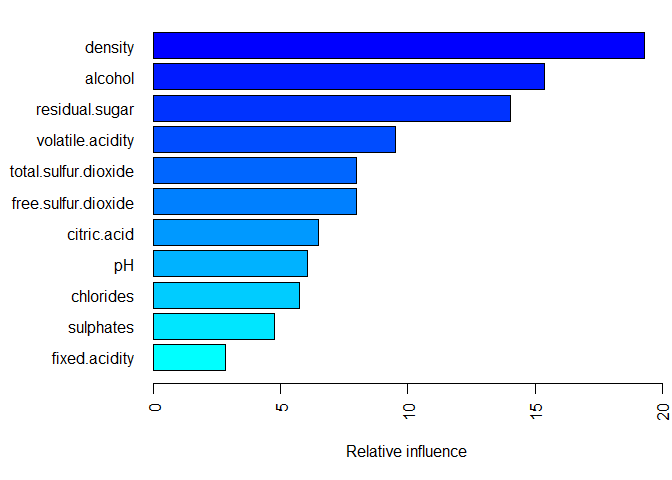

```
##                     var   rel.inf
## 1               density 19.305680
## 2               alcohol 15.382721
## 3        residual.sugar 14.021355
## 4      volatile.acidity  9.509915
## 5  total.sulfur.dioxide  7.960605
## 6   free.sulfur.dioxide  7.958746
## 7           citric.acid  6.496329
## 8                    pH  6.043566
## 9             chlorides  5.733105
## 10            sulphates  4.756836
## 11        fixed.acidity  2.831141
```

```r
# doParallel does not store the models we have run so recreate the winner model below

library(gbm)

ind1 <- sample(nrow(train), nrow(train), replace = TRUE)
train1 <- train[ind1, ]

model4 <- gbm(quality~., distribution ="bernoulli", n.trees=1000,
            interaction.depth = tunedgbm[1], shrinkage = tunedgbm[3],
            data = train1)

# Create Variable Importance Graph

par(mar = c(5, 8, 1, 0.5)) # Set margins around plot
summary(
  model4,
  cBars = 11, # Amount of bars to show
  method = permutation.test.gbm, # also can use relative.influence
  las = 2, # Orient Labels
  xlim = c(0, 20) # Set min and max for X-axis
  )
```

### Running Test on Winner

Based on our validation of various models we have concluded who is the winner. However, let us run the model against our whole data set now.

```r
# Detect and Store all but one core

ncores <- makeCluster(detectCores() - 1)

# Register # of cores

registerDoParallel(ncores)

# Set n for number of bags

n <- 500

# Empty containers are needed before loop starts

AUCw <- c()

# Create Loop

auc_w <-
  foreach(i = 1:n, .combine = c,
          .packages = c("doParallel", "ROCR", "gbm")) %dopar% {

    # First CV

    ind <- sample(nrow(dfw), nrow(dfw), replace = TRUE)
    train <- dfw[ind, ]
    test <- dfw[-ind, ]

    # Create Model for each loop

    modelw<- gbm(quality~., distribution ="bernoulli", n.trees=1000,
            interaction.depth = tunedgbm[1], shrinkage = tunedgbm[3],
            data = train)

    # Predict Model for each loop

    phatw <- predict(modelw, test, n.trees = tunedgbm[2], type = "response")

    # Predict and Calculate AUC for each loop

    pred_rocrw <- prediction(phatw, test$quality)
    auc_ROCRw<- performance(pred_rocrw, measure = "auc")
    AUCw[i] <- auc_ROCRw@y.values[[1]]
}


# Unregister # of cores

stopCluster(ncores)

# Mean of AUC

MAUCw <- percent(mean(auc_w), accuracy = 0.01)

# Standard Deviation of AUC

uncerw <- percent(sd(auc_w), accuracy = 0.01)

# Combine results in matrix

resultsw <- cbind.data.frame("Model" = "GBM", "MAUC" = MAUCw, "SD" = uncerw)

resultsw
```

```
##   Model   MAUC    SD
## 1   GBM 84.85% 0.77%
```

#### Optimal Threshold and Confusion Table of winner

The Optimal Threshold (OT) let’s us know the best value to start the split between our two Classification groups. In this instance, OT will represent the value in which we should convert our probabilities to “above average” if greater than to OT.

The Confusion Table provides us with an understanding of our models’ classification success. We will be informed of information such as true positives/negatives and false positives/negatives, with this information we can derive further metrics such as Accuracy, Precision, Recall, etc. that can let us know how “correct” our model is in prediction.

```r
library(scales)
# Re-run Winner Model

    # First CV

    ind <- sample(nrow(dfw), nrow(dfw), replace = TRUE)
    train <- dfw[ind, ]
    test <- dfw[-ind, ]

    # Create Model

    modelw<- gbm(quality~., distribution ="bernoulli", n.trees=1000,
            interaction.depth = tunedgbm[1], shrinkage = tunedgbm[3],
            data = train)

    # Predict Model

    phatw <- predict(modelw, test, n.trees = tunedgbm[2], type = "response")

# Set phatw in descending order

grid <- phatw[order(phatw)]
n <- length(grid)

TPR <- c()
FPR <- c()

# Compute TPR and FPR

for (i in 1:n) {
  yhat <- phatw > grid[i]
  ct <- table(yhat, test$quality)
  if(sum(dim(ct)) > 3){
    TPR[i] <- ct[2,2]/(ct[2,2]+ct[1,2])
    FPR[i] <- ct[2,1]/(ct[1,1]+ct[2,1])
  }
}

# Youden's J Statistics to convert P-hat into Y-hat

J <- TPR - FPR
opth <- grid[which.max(J)]
opth
```

```
## [1] 0.7141655
```

```r
# Convert P-hat to Y-hat using Optimal Threshold

yhat <- ifelse(phatw > opth, 1, 0)

# Confusion Table

ctable <- table(yhat, test$quality)

# Nicer Looking Confusion Table

rot <- function(x){
  t <- apply(x, 2, rev)
  tt <- apply(t, 1, rev)
  return(t(tt))
}
ct <- rot(ctable)
rownames(ct) <- c("Yhat = 1", "Yhat = 0")
colnames(ct) <- c("Y = 1", "Y = 0")
ct
```

```
##
## yhat       Y = 1 Y = 0
##   Yhat = 1   918   137
##   Yhat = 0   277   468
```

Let us derive some metrics based on our confusion matrix

```r
# Manual Computations

# Accuracy

ACC <- sum(diag(ct))/sum(ct)

# Recall

REC <- ct[1, 1]/sum(ct[, 1])

# Precision

PRE <- ct[1, 1]/sum(ct[1, ])

# F-1 Score

F_1 <- 2*(PRE*REC/(PRE+REC))

# caret can compute most metrics using the function below

library(caret)

metrics <- confusionMatrix(as.factor(yhat), as.factor(test$quality), positive = "1")

# Extract wanted metrics and combine

metrics <- c(metrics$overall[1], metrics$byClass)

# Transpose to column vector

t(t(metrics))
```

```
##                           [,1]
## Accuracy             0.7700000
## Sensitivity          0.7682008
## Specificity          0.7735537
## Pos Pred Value       0.8701422
## Neg Pred Value       0.6281879
## Precision            0.8701422
## Recall               0.7682008
## F1                   0.8160000
## Prevalence           0.6638889
## Detection Rate       0.5100000
## Detection Prevalence 0.5861111
## Balanced Accuracy    0.7708773
```

# Predicting Wine Type: Red or White

To predict wine type we will style our analysis using Classification . Our dependent variable is no longer “Quality”, it is “Type”.

## Classification Problem

Before running our analysis we must prepare our data to fit our question, as mentioned above our predicted variable will be “Type” and we must create it.

To create “Type” we will do the following:

1. Create a Binary outcome for Red Wines then for White Wines
2. Combine both Data frames together into one larger data frame

### Pre-processing Steps

```r
remove(list = ls())
library(readr)

# Load Data

dfw <- read.csv("C:/Users/jadel/OneDrive - Saint Marys University/Intro to Machine Learning/Data Sets/winequality-white.csv", sep = ";")
dfr <- read.csv("C:/Users/jadel/OneDrive - Saint Marys University/Intro to Machine Learning/Data Sets/winequality-red.csv", sep = ";" )

# Create Binary outcomes for Red and White wine

red <- rep(1, nrow(dfr)) # Red = 1
white <- rep(0, nrow(dfw)) # White = 0

# Create new column with new Binary Variable

dfr$type <- red
dfw$type <- white

# Append both DF into one

df <- rbind(dfr, dfw)

#df$type <- as.factor(df$type)

# Original Split of Data

ind <- sample(nrow(df), nrow(df)*0.90, replace = FALSE)
train <- df[ind, ]
test <- df[-ind, ]
```

### Estimating Models

#### Linear Probability Model

```r
# Detect and Store all but one core

ncores <- makeCluster(detectCores() - 1)

# Register # of cores

registerDoParallel(ncores)

# Set n for number of bags

n <- 500

# Empty containers are needed before loop starts

AUC0 <- c()

# Create Loop

auc_ols <-
  foreach(i = 1:n, .combine = c, .packages = c("doParallel", "ROCR")) %dopar% {

    # Second CV and Split

    ind1 <- sample(nrow(train), nrow(train), replace = TRUE)
    train1 <- train[ind1, ]
    test1 <- train[-ind1, ]

    # Create Model for each loop

    model0 <- lm(type~., data = train1)

    # Predict Model for each loop

    phat0 <- predict(model0, test1)


    # Predict and Calculate AUC for each loop

    pred_rocr0 <- prediction(phat0, test1$type)
    auc_ROCR0 <- performance(pred_rocr0, measure = "auc")
    AUC0[i] <- auc_ROCR0@y.values[[1]]
}


# Unregister # of cores

stopCluster(ncores)

# Mean of AUC

MAUC0 <- percent(mean(auc_ols), accuracy = 0.01)

# Standard Deviation of AUC

uncer0 <- percent(sd(auc_ols), accuracy = 0.01)

# Create Results to compare the end of testing

results <- rbind(c("MAUC" = MAUC0, "SD" = uncer0))

# Create row name vector for results DF

rnames <- "LPM"

results
```

```
##      MAUC     SD
## [1,] "99.57%" "0.16%"
```

#### Classification and Regression Tree (CART)

##### Tuning Hyper-parameters

```r
# Detect and Store all but one core

ncores <- makeCluster(detectCores() - 1)

# Register cores

registerDoParallel(ncores)

# Number of loops per grid combination

n <- 10

# Create Hyper-parameters

CP <- seq(0.01, 0.3, 0.01) # Complexity Parameter
MS <- c(100, 300, 500, 750, 900) # Min Split
MD <- 1:30 # Max Depth

# Input Hyper-parameters into matrix and form a grid

grid <- as.matrix(expand.grid(MD, MS, CP))

# Empty Containers for loops to run

mauc <- c()
sdauc <- c()
tuneresults <- c()

# Function to combine results of foreach loops in a master list
# This separates our two outputs into its correct list in our master list

comb <- function(x, ...) {
  lapply(seq_along(x),
    function(i) c(x[[i]], lapply(list(...), function(y) y[[i]])))
}

# Parallelized Loop

tuneresults <- foreach(i = 1:nrow(grid), .combine = comb,
                       .packages = c("rpart", "doParallel", "ROCR"),
                       .multicombine = TRUE,.init=list(list(), list())) %dopar% {

                         auc <- c() # Store calculated AUC from each loop

                         for (j in 1:n) { # run grid selection this many times

                           # Second CV

                           ind1 <- sample(nrow(train), nrow(train), replace = TRUE)
                           train1 <- train[ind1, ]
                           test1 <- train[-ind1, ]

                           # Create model for each loop

                          cart <- rpart(type~., minsplit = grid[i, 2],
                                        cp = grid[i, 3], maxdepth = grid[i, 1],
                                        data = train1, method = "class")

                          # Predict P-hats for each loop

                          cartpr <- predict(cart, test1, type = "prob") [, 2]

                          # Predict and Calculate AUC for each loop

                          pred_rocr1 <- prediction(cartpr, test1$type)
                          auc_ROCR1 <- performance(pred_rocr1, measure = "auc")
                          auc[j] <- auc_ROCR1@y.values[[1]]
                         }

                         # Find Mean and SD of all AUC's per grid selection

                          mauc[i] <- mean(auc)
                          sdauc[i] <- sd(auc)

                         # Store Results in a list

                         list(mauc[i], sdauc[[i]])
                       }

# Detach/Unregister cores

stopCluster(ncores)

# Extract AUC and Turn into vector

mauc <- unlist(tuneresults[[1]])
sdauc <- unlist(tuneresults[[2]])

# Max MAUC and Mean of SD

mmauc <- max(mauc)
msdauc <- mean(sdauc)

# Create table and showcase results
# Find the Hyper-parameters that give the Highest AUC

tunedcart <- rbind(c(grid[which.max(mauc), ], mmauc, msdauc))
colnames(tunedcart) <- c("MD", "MS", "CP","Max MAUC", "SD")

tunedcart
```

```
##      MD  MS   CP  Max MAUC         SD
## [1,] 13 100 0.01 0.9798979 0.01955067
```

##### Validating Model

```r
# Detect and Store all but one core

ncores <- makeCluster(detectCores() - 1)

# Register # of cores

registerDoParallel(ncores)

# Set n for number of bags

n <- 500

# Empty containers are needed before loop starts

AUC1 <- c()

# Create Loop

auc_cart <-
  foreach(i = 1:n, .combine = c,
          .packages = c("doParallel", "ROCR", "rpart")) %dopar% {

    # Second CV and Split

    ind1 <- sample(nrow(train), nrow(train), replace = TRUE)
    train1 <- train[ind1, ]
    test1 <- train[-ind1, ]

    # Create Model for each loop

    model1 <- rpart(type~., minsplit = tunedcart[2], cp = tunedcart[3],
                    maxdepth = tunedcart[1], data = train1, method = "class")

    # Predict Model for each loop

    phat1 <- predict(model1, test1, type = "prob")[, 2]

  # Predict and Calculate AUC for each loop

    pred_rocr1 <- prediction(phat1, test1$type)
    auc_ROCR1 <- performance(pred_rocr1, measure = "auc")
    AUC1[i] <- auc_ROCR1@y.values[[1]]
}


# Unregister # of cores

stopCluster(ncores)

# Mean of AUC

MAUC1 <- percent(mean(auc_cart), accuracy = 0.01)

# Standard Deviation of AUC

uncer1 <- percent(sd(auc_cart), accuracy = 0.01)

# Create Results to compare the end of testing

values1 <- rbind(c("MAUC" = MAUC1, "SD" = uncer1))

# Match colnames to append new values into Results

names(values1) <- names(results)
results <- rbind(results, values1)

# Update Row Names

rnames <- append(rnames, "CART", length(rnames))

values1
```

```
##      MAUC     SD
## [1,] "97.66%" "0.53%"
```

#### K-Nearest Neighbors

##### Tuning Hyper-parameters

```r
# Detect and Store all but one core

ncores <- makeCluster(detectCores() - 1)

# Register cores

registerDoParallel(ncores)

# Number of loops per grid combination

n <- 10

# Create Hyper-parameters

k <- seq(from = 2, to = sqrt(nrow(train)), by = 1) # Number of neighbors considered

# Empty Containers for loops to run

mauc <- c()
sdauc <- c()
tuneresults <- c()

# Parallelized Loop

tuneresults <- foreach(i = 1:length(k), .combine = comb,
                       .packages = c("caret", "doParallel", "ROCR"),
                       .multicombine = TRUE,.init=list(list(), list())) %dopar% {

                         auc <- c() # Store calculated AUC from each loop

                         for (j in 1:n) { # run grid selection this many times

                           # Second CV

                           ind1 <- sample(nrow(train), nrow(train), replace = TRUE)
                           train1 <- train[ind1, ]
                           test1 <- train[-ind1, ]

                           # Create model for each loop

                           knnt <- knn3(type~., data = train1, k = k[i])

                           # Predict P-hats for each loop

                           knnpr <- predict(knnt, test1, method = "prob")[, 2]

                           # Predict and Calculate AUC for each loop

                           pred_rocr2 <- prediction(knnpr, test1$type)
                           auc_ROCR2 <- performance(pred_rocr2, measure = "auc")
                           auc[j] <- auc_ROCR2@y.values[[1]]
                         }

                         # Find Mean and SD of all AUC's per grid selection

                          mauc[i] <- mean(auc)
                          sdauc[i] <- sd(auc)

                         # Store Results in a list

                         list(mauc[i], sdauc[[i]])
                       }

# Detach/Unregister cores

stopCluster(ncores)

# Extract AUC and Turn into vector

mauc <- unlist(tuneresults[[1]])
sdauc <- unlist(tuneresults[[2]])

# Max MAUC and Mean of SD

mmauc2 <- max(mauc)
msdauc2 <- mean(sdauc)

# Create table and showcase results
# Find the Hyper-parameters that give the Highest AUC

tunedknn <- rbind(c(k[which.max(mauc) ], mmauc2, msdauc2))
colnames(tunedknn) <- c("K", "Max MAUC", "SD")

tunedknn
```

```
##       K  Max MAUC          SD
## [1,] 44 0.9669015 0.004567649
```

##### Validating Model

```r
# Detect and Store all but one core

ncores <- makeCluster(detectCores() - 1)

# Register # of cores

registerDoParallel(ncores)

# Set n for number of bags

n <- 500

# Empty containers are needed before loop starts

AUC2 <- c()

# Create Loop

auc_k <-
  foreach(i = 1:n, .combine = c,
          .packages = c("doParallel", "ROCR", "caret")) %dopar% {

    # Second CV and Split

    ind1 <- sample(nrow(train), nrow(train), replace = TRUE)
    train1 <- train[ind1, ]
    test1 <- train[-ind1, ]

    # Create Model for each loop

    model2 <- knn3(type~., data = train1, k = tunedknn[1])

    # Predict Model for each loop

    phat2 <- predict(model2, test1, type = "prob")[, 2]

    # Predict and Calculate AUC for each loop

    pred_rocr2 <- prediction(phat2, test1$type)
    auc_ROCR2 <- performance(pred_rocr2, measure = "auc")
    AUC2[i] <- auc_ROCR2@y.values[[1]]
}


# Unregister # of cores

stopCluster(ncores)

# Mean of AUC

MAUC2 <- percent(mean(auc_k), accuracy = 0.01)

# Standard Deviation of AUC

uncer2 <- percent(sd(auc_k), accuracy = 0.01)

# Create Results to compare the end of testing

values2 <- rbind(c("MAUC" = MAUC2, "SD" = uncer2))

# Match colnames to append new values into Results

names(values2) <- names(results)
results <- rbind(results, values2)

# Update Row Names

rnames <- append(rnames, "KNN", length(rnames))

values2
```

```
##      MAUC     SD
## [1,] "96.32%" "0.45%"
```

#### Random Forest (RF)

##### Tuning Hyper-parameters

```r
# Detect and Store all but one core

ncores <- makeCluster(detectCores() - 1)

# Register cores

registerDoParallel(ncores)

# Number of loops per grid combination

n <- 10

# Create Hyper-parameters

NT <- seq(1000, 2000, 200) # Number of Trees
p <- ncol(train)-1 # Amount of x-variables
MT <- sqrt(p):p # Number of X-variables used sqrt(p) is default for Classification

# Input Hyper-parameters into matrix and form a grid

grid <- as.matrix(expand.grid(NT, MT))

# Empty Containers for loops to run

mauc <- c()
sdauc <- c()
tuneresults <- c()

# Parallelized Loop

tuneresults <- foreach(i = 1:nrow(grid), .combine = comb,
                       .packages = c("ranger", "doParallel", "ROCR"),
                       .multicombine = TRUE,.init=list(list(), list())) %dopar% {

                         auc <- c() # Store calculated AUC from each loop

                         for (j in 1:n) { # run grid selection this many times

                           # Second CV

                           ind1 <- sample(nrow(train), nrow(train), replace = TRUE)
                           train1 <- train[ind1, ]
                           test1 <- train[-ind1, ]

                           # Create model for each loop
                           rft <- ranger(y = train1[, 13], x = train1[, 1:12],
                                         num.trees = grid[i, 1], mtry = grid[i, 2],
                                         probability = TRUE)

                           # Predict P-hats for each loop
                           rfpr <- predict(rft, test1,
                                           type = "response")$predictions[, 2]

                           # Predict and Calculate AUC for each loop

                           pred_rocr3 <- prediction(rfpr, test1$type)
                           auc_ROCR3 <- performance(pred_rocr3, measure = "auc")
                           auc[j] <- auc_ROCR3@y.values[[1]]
                         }

                         # Find Mean and SD of all AUC's per grid selection

                          mauc[i] <- mean(auc)
                          sdauc[i] <- sd(auc)

                         # Store Results in a list

                         list(mauc[i], sdauc[[i]])
                       }

# Detach/Unregister cores

stopCluster(ncores)

# Extract AUC and Turn into vector

mauc <- unlist(tuneresults[[1]])
sdauc <- unlist(tuneresults[[2]])

# Max MAUC and Mean of SD

mmauc3 <- max(mauc)
msdauc3 <- mean(sdauc)

# Create table and showcase results
# Find the Hyper-parameters that give the Highest AUC

tunedrf <- rbind(c(grid[which.max(mauc), ], mmauc3, msdauc3))
colnames(tunedrf) <- c("NT","MT", "Max MAUC", "SD")

tunedrf
```

```
##        NT       MT  Max MAUC        SD
## [1,] 1200 7.464102 0.9976599 0.4059473
```

##### Validating Model

```r
# Detect and Store all but one core

ncores <- makeCluster(detectCores() - 1)

# Register # of cores

registerDoParallel(ncores)

# Set n for number of bags

n <- 500

# Empty containers are needed before loop starts

AUC3 <- c()

# Create Loop

auc_rf <-
  foreach(i = 1:n, .combine = c,
          .packages = c("doParallel", "ROCR", "ranger")) %dopar% {

    # Second CV and Split

    ind1 <- sample(nrow(train), nrow(train), replace = TRUE)
    train1 <- train[ind1, ]
    test1 <- train[-ind1, ]

    # Create Model for each loop

    model3 <- ranger(y = train1[, 13], x = train1[, 1:12],
                   num.trees = tunedrf[1], mtry = tunedrf[2], probability = TRUE)

    # Predict Model for each loop

    phat3 <- predict(model3, test1, type = "response")$predictions[, 2]

    # Predict and Calculate AUC for each loop

    pred_rocr3 <- prediction(phat3, test1$type)
    auc_ROCR3 <- performance(pred_rocr3, measure = "auc")
    AUC3[i] <- auc_ROCR3@y.values[[1]]
}


# Unregister # of cores

stopCluster(ncores)

# Mean of AUC

MAUC3 <- percent(mean(auc_rf), accuracy = 0.01)

# Standard Deviation of AUC

uncer3 <- percent(sd(auc_rf), accuracy = 0.01)

# Create Results to compare the end of testing

values3 <- rbind(c("MAUC" = MAUC3, "SD" = uncer3))

# Match colnames to append new values into Results

names(values3) <- names(results)
results <- rbind(results, values3)

# Update Row Names

rnames <- append(rnames, "RF", length(rnames))

values3
```

```
##      MAUC     SD
## [1,] "72.91%" "44.27%"
```

#### Gradient Boosting Machines (GBM)

##### Tuning Hyper-parameters

```r
# Detect and Store all but one core

ncores <- makeCluster(detectCores() - 1)

# Register cores

registerDoParallel(ncores)

# Number of loops per grid combination

n <- 10

# Create Hyper-parameters

SH <- seq(0.01, 0.3, 0.01) # Shrinkage default = 0.1
NT <- c(100, 300, 500, 750, 900) # Number of predicted trees default = 100
ID <- 1:sqrt(ncol(train)) # Interaction Depth default = 1

# Input Hyper-parameters into matrix and form a grid

grid <- as.matrix(expand.grid(ID, NT, SH))

# Empty Containers for loops to run

mauc <- c()
sdauc <- c()
tuneresults <- c()

# Parallelized Loop

tuneresults <- foreach(i = 1:nrow(grid), .combine = comb,
                       .packages = c("gbm", "doParallel", "ROCR"),
                       .multicombine = TRUE,.init=list(list(), list())) %dopar% {

                         auc <- c() # Store calculated AUC from each loop

                         for (j in 1:n) { # run grid selection this many times

                           # Second CV

                           ind1 <- sample(nrow(train), nrow(train), replace = TRUE)
                           train1 <- train[ind1, ]
                           test1 <- train[-ind1, ]

                           # Create model for each loop

                           boos <- gbm(type~., distribution ="bernoulli",
                                       n.trees=1000,interaction.depth = grid[i,1],
                                       shrinkage = grid[i,3], data = train1)

                           # Predict P-hats for each loop

                           prboos <- predict(boos, test1, n.trees = grid[i,2],
                                             type = "response")

                           # Predict and Calculate AUC for each loop

                           pred_rocr4 <- prediction(prboos, test1$type)
                           auc_ROCR4 <- performance(pred_rocr4, measure = "auc")
                           auc[j] <- auc_ROCR4@y.values[[1]]
                         }

                         # Find Mean and SD of all AUC's per grid selection

                          mauc[i] <- mean(auc)
                          sdauc[i] <- sd(auc)

                         # Store Results in a list

                         list(mauc[i], sdauc[[i]])
                       }

# Detach/Unregister cores

stopCluster(ncores)

# Extract AUC and Turn into vector

mauc <- unlist(tuneresults[[1]])
sdauc <- unlist(tuneresults[[2]])

# Max MAUC and Mean of SD

mmauc4 <- max(mauc)
msdauc4 <- mean(sdauc)

# Create table and showcase results
# Find the Hyper-parameters that give the Highest AUC

tunedgbm <- rbind(c(grid[which.max(mauc), ], mmauc4, msdauc4))
colnames(tunedgbm) <- c("MD", "MS", "CP","Max MAUC", "SD")

tunedgbm
```

```
##      MD  MS   CP  Max MAUC          SD
## [1,]  3 750 0.03 0.9990183 0.003720009
```

##### Validating Model

```r
# Detect and Store all but one core

ncores <- makeCluster(detectCores() - 1)

# Register # of cores

registerDoParallel(ncores)

# Set n for number of bags

n <- 500

# Empty containers are needed before loop starts

AUC4 <- c()

# Create Loop

auc_gbm <-
  foreach(i = 1:n, .combine = c,
          .packages = c("doParallel", "ROCR", "gbm")) %dopar% {

    # Second CV and Split

    ind1 <- sample(nrow(train), nrow(train), replace = TRUE)
    train1 <- train[ind1, ]
    test1 <- train[-ind1, ]

    # Create Model for each loop

    model4 <- gbm(type~., distribution ="bernoulli", n.trees=1000,
            interaction.depth = tunedgbm[1], shrinkage = tunedgbm[3],
            data = train1)

    # Predict Model for each loop

    phat4 <- predict(model4, test1, n.trees = tunedgbm[2], type = "response")

    # Predict and Calculate AUC for each loop

    pred_rocr4 <- prediction(phat4, test1$type)
    auc_ROCR4 <- performance(pred_rocr4, measure = "auc")
    AUC4[i] <- auc_ROCR4@y.values[[1]]
}


# Unregister # of cores

stopCluster(ncores)

# Mean of AUC

MAUC4 <- percent(mean(auc_gbm), accuracy = 0.01)

# Standard Deviation of AUC

uncer4 <- percent(sd(auc_gbm), accuracy = 0.01)

# Create Results to compare the end of testing

values4 <- rbind(c("MAUC" = MAUC4, "SD" = uncer4))

# Match colnames to append new values into Results

names(values4) <- names(results)
results <- rbind(results, values4)

# Update Row Names

rnames <- append(rnames, "GBM", length(rnames))

values4
```

```
##      MAUC     SD
## [1,] "99.79%" "0.17%"
```

### Compare Results and Pick a Winner

The winner model is Boosting with the highest Mean Area Under Curve.

```r
# Combine all results with its corresponding model

rownames(results) <- rnames

datatable(results, colnames = c("Model" = 1))
```

| Model | MAUC | SD |
| --- | --- | --- |
| LPM | 99.57% | 0.16% |
| CART | 97.66% | 0.53% |
| KNN | 96.32% | 0.45% |
| RF | 72.91% | 44.27% |
| GBM | 99.79% | 0.17% |

### Most Important Predictors

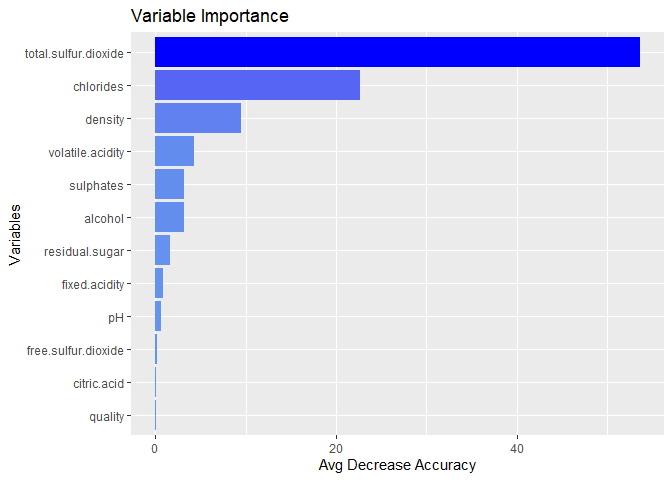

```r
# doParallel does not store the models we have run so recreate the winner model below

library(gbm)
library(ggplot2)

ind1 <- sample(nrow(train), nrow(train), replace = TRUE)
train1 <- train[ind1, ]

model4 <- gbm(type~., distribution ="bernoulli", n.trees=1000,
            interaction.depth = tunedgbm[1], shrinkage = tunedgbm[3],
            data = train1)

# Another method to show Varimp for GBM

imppred <- as.data.frame(summary.gbm(model4, plotit = FALSE,
                                     method = permutation.test.gbm))

colnames(imppred) <- c("variables","importance")

# Plot values on Bar graph

ggplot(imppred, aes(x=reorder(variables,importance), y=importance,fill=importance))+
  geom_bar(stat="identity", position="dodge")+ coord_flip()+
  ylab("Avg Decrease Accuracy")+
  xlab("Variables")+
  ggtitle("Variable Importance")+
  guides(fill=F)+
  scale_fill_gradient(low=" cornflowerblue", high="blue")
```

### Running Test on Winner

Based on our validation of various models we have concluded who is the winner. However, let us run our model against the whole dataset now.

```r
# Detect and Store all but one core

ncores <- makeCluster(detectCores() - 1)

# Register # of cores

registerDoParallel(ncores)

# Set n for number of bags

n <- 500

# Empty containers are needed before loop starts

AUCw <- c()

# Create Loop

auc_w <-
  foreach(i = 1:n, .combine = c,
          .packages = c("doParallel", "ROCR", "gbm")) %dopar% {

    # First CV

    ind <- sample(nrow(df), nrow(df), replace = TRUE)
    train <- df[ind, ]
    test <- df[-ind, ]

    # Create Model for each loop

    modelw<- gbm(type~., distribution ="bernoulli", n.trees=1000,
            interaction.depth = tunedgbm[1], shrinkage = tunedgbm[3],
            data = train)

    # Predict Model for each loop

    phatw <- predict(modelw, test, n.trees = tunedgbm[2], type = "response")

    # Predict and Calculate AUC for each loop

    pred_rocrw <- prediction(phatw, test$type)
    auc_ROCRw<- performance(pred_rocrw, measure = "auc")
    AUCw[i] <- auc_ROCRw@y.values[[1]]
}


# Unregister # of cores

stopCluster(ncores)

# Mean of AUC

MAUCw <- percent(mean(auc_w), accuracy = 0.01)

# Standard Deviation of AUC

uncerw <- percent(sd(auc_w), accuracy = 0.01)

# Combine results in matrix

resultsw <- cbind.data.frame("Model" = "GBM", "MAUC" = MAUCw, "SD" = uncerw)

resultsw
```

```
##   Model   MAUC    SD
## 1   GBM 99.82% 0.15%
```

#### Optimal Threshold and Confusion Table of winner

```r
# Re-run Winner Model

    # First CV

    ind <- sample(nrow(df), nrow(df), replace = TRUE)
    train <- df[ind, ]
    test <- df[-ind, ]

    # Create Model

    modelw<- gbm(type~., distribution ="bernoulli", n.trees=1000,
            interaction.depth = tunedgbm[1], shrinkage = tunedgbm[3],
            data = train)

    # Predict Model

    phatw <- predict(modelw, test, n.trees = tunedgbm[2], type = "response")

# Set phatw in descending order

grid <- phatw[order(phatw)]
n <- length(grid)

# Compute TPR and FPR

TPR <- c()
FPR <- c()

for (i in 1:n) {
  yhat <- phatw > grid[i]
  ct <- table(yhat, test$type)
  if(sum(dim(ct)) > 3){
    TPR[i] <- ct[2,2]/(ct[2,2]+ct[1,2])
    FPR[i] <- ct[2,1]/(ct[1,1]+ct[2,1])
  }
}

# Youden's J Statistic to convert phat into yhat

J <- TPR - FPR
opth <- grid[which.max(J)]
opth
```

```
## [1] 0.4592
```

```r
# Convert P-hat to Y-hat using Optimal Threshold

yhat <- ifelse(phatw > opth, 1, 0)

# Confusion Table

ctable <- table(yhat, test$type)

# Nicer Looking Confusion Table

rot <- function(x){
  t <- apply(x, 2, rev)
  tt <- apply(t, 1, rev)
  return(t(tt))
}
ct <- rot(ctable)
rownames(ct) <- c("Yhat = 1", "Yhat = 0")
colnames(ct) <- c("Y = 1", "Y = 0")
ct
```

```
##
## yhat       Y = 1 Y = 0
##   Yhat = 1   597     5
##   Yhat = 0     6  1792
```

Here is a list of metrics based off of the confusion matrix

```r
# Manual Computations

# Accuracy

ACC <- sum(diag(ct))/sum(ct)

# Recall

REC <- ct[1, 1]/sum(ct[, 1])

# Precision

PRE <- ct[1, 1]/sum(ct[1, ])

# F-1 Score

F_1 <- 2*(PRE*REC/(PRE+REC))

# caret can compute most metrics using the function below

library(caret)

metrics <- confusionMatrix(as.factor(yhat), as.factor(test$type), positive = "1")

# Extract wanted metrics and combine

metrics <- c(metrics$overall[1], metrics$byClass)

# Transpose to column vector

t(t(metrics))
```

```
##                           [,1]
## Accuracy             0.9954167
## Sensitivity          0.9900498
## Specificity          0.9972176
## Pos Pred Value       0.9916944
## Neg Pred Value       0.9966630
## Precision            0.9916944
## Recall               0.9900498
## F1                   0.9908714
## Prevalence           0.2512500
## Detection Rate       0.2487500
## Detection Prevalence 0.2508333
## Balanced Accuracy    0.9936337
```